# logistic_regression

```
##
##                 Causas externas                        Crónicas
##                             0.2                             0.2
##                     Infecciosas                      Neoplasias
##                             0.2                             0.2
## Síntomas y causas mal definidas
##                             0.2
```

```
##
##                 Causas externas                        Crónicas
##                             0.2                             0.2
##                     Infecciosas                      Neoplasias
##                             0.2                             0.2
## Síntomas y causas mal definidas
##                             0.2
```

```
##  [1] "Asist"       "Depocu"      "Diaocu"      "Dnadif"      "Dredif"
##  [6] "Ecidif"      "Edadif"      "Mesocu"      "Ocur"        "Sexo"
## [11] "year"        "Escodif"     "causa_macro"
```

```
## Registros con Edadif en train = 999: 1174
## Porcentaje del total: 0.8 %
```

```
## Registros con Edadif en test = 999: 544
## Porcentaje del total: 0.87 %
```

```
##       Asist      Depocu      Diaocu      Dnadif      Dredif      Ecidif
##           0           0           0           0           0           0
##      Edadif      Mesocu        Ocur        Sexo        year     Escodif
##           0           0           0           0           0        9252
## causa_macro
##           0
```

```
##       Asist      Depocu      Diaocu      Dnadif      Dredif      Ecidif
##           0           0           0           0           0           0
##      Edadif      Mesocu        Ocur        Sexo        year     Escodif
##           0           0           0           0           0        4008
## causa_macro
##           0
```

```
##       Asist      Depocu      Diaocu      Dnadif      Dredif      Ecidif
##           0           0           0           0           0           0
##      Edadif      Mesocu        Ocur        Sexo        year     Escodif
##           0           0           0           0           0           0
## causa_macro
##           0
```

```
##       Asist      Depocu      Diaocu      Dnadif      Dredif      Ecidif
##           0           0           0           0           0           0
##      Edadif      Mesocu        Ocur        Sexo        year     Escodif
##           0           0           0           0           0           0
## causa_macro
##           0
```

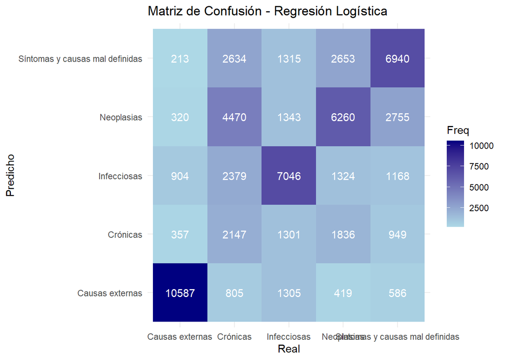

```
## Accuracy global: 0.532
```

```
##                                        Sensitivity Specificity        F1
## Class: Causas externas                   0.8551006   0.9372419 0.8117931
## Class: Crónicas                          0.1726578   0.9103891 0.2257030
## Class: Infecciosas                       0.5723802   0.8838168 0.5607417
## Class: Neoplasias                        0.5011207   0.8205315 0.4529667
## Class: Síntomas y causas mal definidas   0.5597677   0.8626507 0.5307231
```

El primer modelo nos dio un accuracy global del 53.2%, lo cual, considerando que estamos trabajando con cinco clases balanceadas, supera el 20% que obtendríamos con predicciones al azar. Sin embargo, al analizar las métricas por clase, encontramos diferencias importantes en el desempeño del modelo. Para la categoría Causas externas el modelo mostró un buen rendimiento con un F1 de 0.81, mientras que para las Crónicas el desempeño fue considerablemente menor con solo 0.22 de F1.

Estas diferencias nos indican que el modelo tiene mayor facilidad para identificar patrones en ciertos tipos de defunción que en otros. Las causas externas, que incluyen accidentes y violencia, probablemente tienen perfiles demográficos más definidos que las enfermedades crónicas. Por otro lado, las categorías de Infecciosas, Neoplasias y Síntomas mal definidas tuvieron un desempeño intermedio, con valores de F1 alrededor de 0.5 a 0.55. Estas no fueron tan buenas clasificando, pero si mejores que las enfermedades crónicas.

La matriz de confusión nos revela detalles importantes sobre los errores más comunes. Podemos observar que el modelo también tiene problemas específicamente con las enfermedades crónicas y neoplásias, siendo esta la principal fuente de error. Esto ya había ocurrido antes, por lo que nos ayuda a demostrar que en efecto en modelos anteriores, el error no era como tal el procesamiento o configuración de entrenamiento sino la propia naturaleza de los datos. Estos errores podrían deberse a que algunas características demográficas de estos grupos se traslapan, haciendo más difícil su diferenciación en algunas causas de defunción específicas.

Aunque el accuracy del 53% puede parecer bajo a primera vista, debemos considerar la complejidad del problema. Clasificar causas de defunción es complejo porque muchos factores demográficos pueden estar presentes en múltiples categorías. El modelo logístico, a pesar de su simplicidad, nos ha dad una buena base solida comparable con el resto de modelos con otros algorítmos empleados hasta el momento.

```
##          Dataset  Accuracy Diferencia
##            Train 0.5372557         NA
## Accuracy    Test 0.5288796 0.00837607
```

```
## [1] "F1-Score por clase:"
```

```
##       Class: Causas externas Class: Crónicas Class: Infecciosas
## Train              0.8151411       0.2457570          0.5586478
## Test               0.8120710       0.2243539          0.5592142
##       Class: Neoplasias Class: Síntomas y causas mal definidas
## Train         0.4685293                              0.5219262
## Test          0.4483059                              0.5243847
```

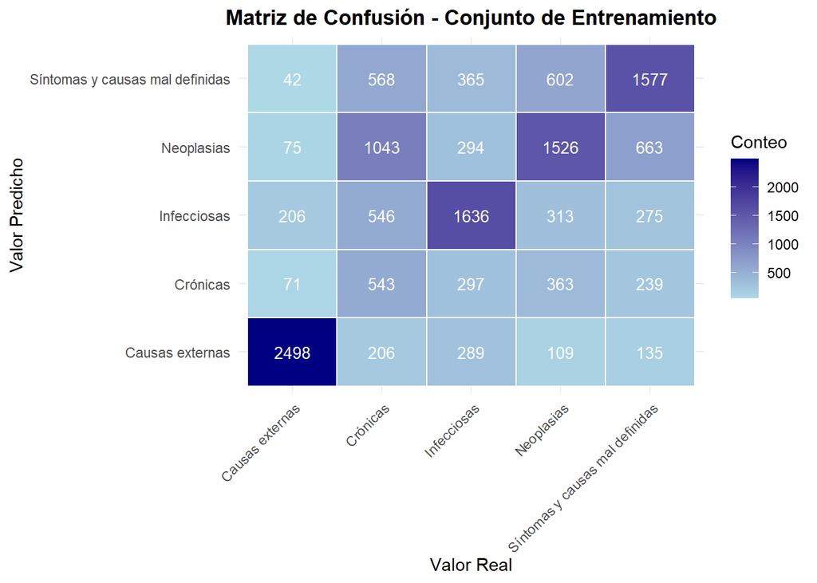

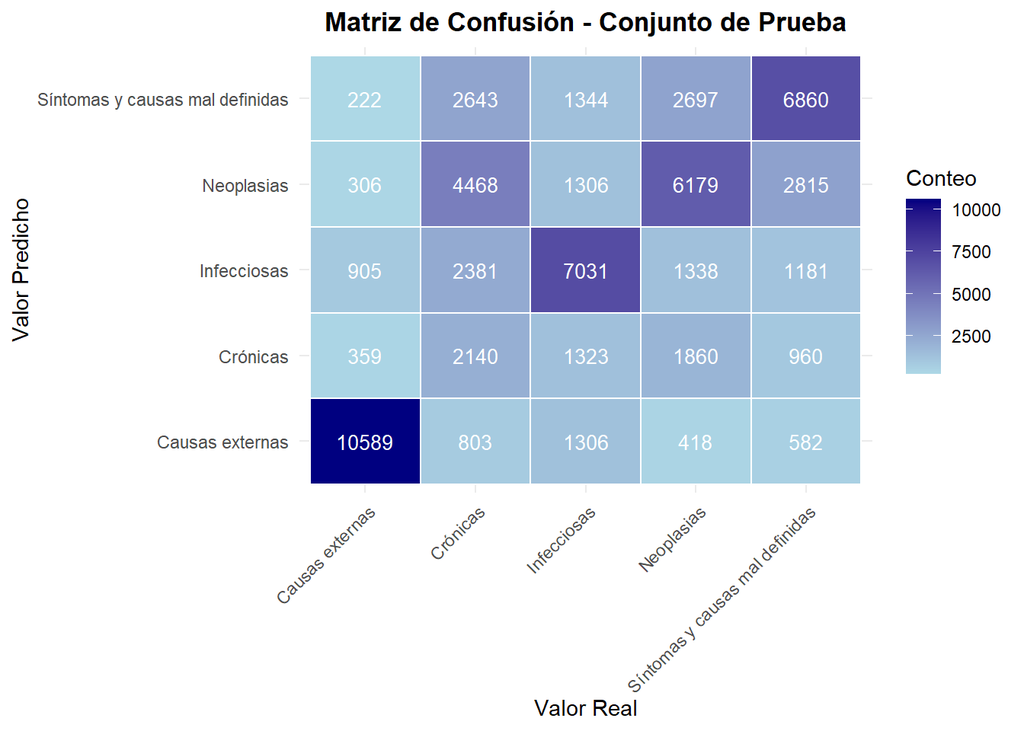

Comparación de Métricas Globales - Modelo 2

|  | Modelo | Train_Accuracy | Test_Accuracy | Diferencia | Kappa |
| --- | --- | --- | --- | --- | --- |
| Accuracy | 2 | 0.537 | 0.529 | 0.008 | 0.411 |

Nota:  
Diferencia = Train Accuracy - Test Accuracy

Métricas por Clase (Test) - Modelo 2

|  | Sensibilidad | Especificidad | F1-Score |
| --- | --- | --- | --- |
| Class: Causas externas | 0.855 | 0.937 | 0.812 |
| Class: Crónicas | 0.172 | 0.909 | 0.224 |
| Class: Infecciosas | 0.571 | 0.883 | 0.559 |
| Class: Neoplasias | 0.495 | 0.820 | 0.448 |
| Class: Síntomas y causas mal definidas | 0.553 | 0.861 | 0.524 |

El segundo modelo mostró un comportamiento particularmente interesante. Con un accuracy del 52.9% en el conjunto de prueba y apenas 0.8% de diferencia con el accuracy de entrenamiento (53.7%), estamos ante un modelo notablemente robusto. Esta mínima diferencia entre train y test nos indica que el modelo generaliza muy bien, sin presentar problemas de sobreajuste a pesar de su mayor complejidad.

El éxito de este modelo radica en el balance que encontramos entre complejidad y generalización. Al incrementar ligeramente las iteraciones de 1500 vs 1000 del primer modelo y ajustar la regularización decay=0.05, logramos un modelo que mantiene el porcentaj de predicción sin sacrificar confiabilidad. El accuracy es tan solo un poco menos que el modelo 1, pero confirmamos no tener sobre ajuste. Antes se tuvo 53% y ahora con este modelo 52.9%, realmente la perdida es mínima.

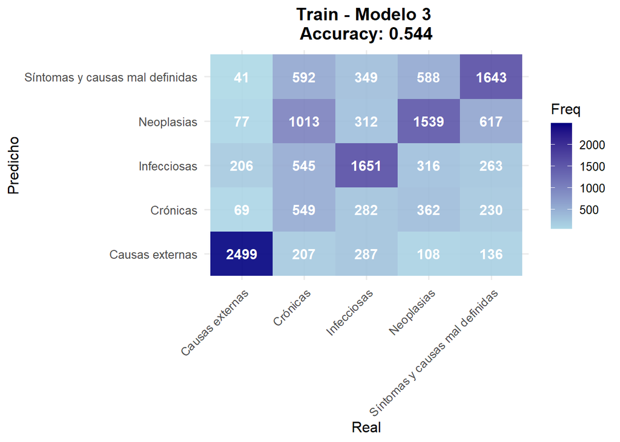

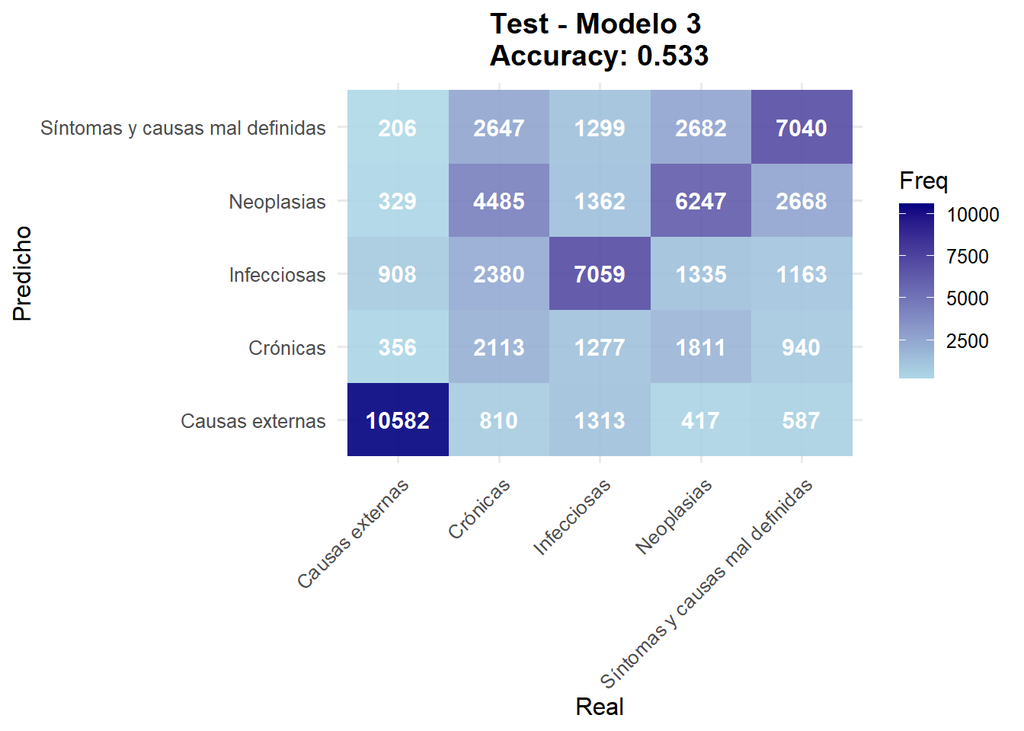

|  | Modelo | Train_Accuracy | Test_Accuracy | Diferencia | Kappa |
| --- | --- | --- | --- | --- | --- |
| Accuracy | 3 | 0.544 | 0.533 | 0.011 | 0.416 |

Métricas por Clase (Test)

|  | Sensitivity | Specificity | F1 |
| --- | --- | --- | --- |
| Class: Causas externas | 0.855 | 0.937 | 0.811 |
| Class: Crónicas | 0.170 | 0.912 | 0.223 |
| Class: Infecciosas | 0.573 | 0.884 | 0.561 |
| Class: Neoplasias | 0.500 | 0.821 | 0.453 |
| Class: Síntomas y causas mal definidas | 0.568 | 0.862 | 0.536 |

El tercer modelo nos revela un patrón importante, hemos alcanzado un techo predictivo alrededor del 53-54% de accuracy, a pesar de los ajustes realizados. Este modelo, con su mayor número de iteraciones (2000) y menor regularización con decay=0.003, logró el mejor accuracy hasta ahora con el set de datos de prueba con un 53.3%, pero confirmó que existen límites en nuestros datos. La diferencia entre train de 54.4% y test (53.3%) se mantuvo en un excelente 1.1%, demostrando que el modelo sigue siendo robusto.

Los resultados por clase muestran un patrón consistente con los modelos anteriores. Las causas externas mantienen un F1 alto (0.81), mientras las Crónicas persisten como la categoría más difícil de predecir (F1 de 0.22). Esta consistencia a través de múltiples modelos sugiere que no es un problema de ajuste, sino de información. Las variables demográficas que tenemos simplemente no contienen suficiente poder para diferenciar para ciertas categorías de razones de defunción.

El valor del Kappa (0.41) nos indica que el modelo supera significativamente la predicción al azar, pero también revela las limitaciones del conjunto de datos.

Curiosamente, el modelo mostró pequeñas mejoras en Síntomas mal definidas (F1 de 0.536 vs 0.524 en el modelo 2) al relajar la regularización, sugiriendo que patrones más complejos existen para esta categoría. Sin embargo, luego de probar distintas configuraciones si se relaja demasiado este parámetro el modelo pierde gradualmente robustez, separando su accuracy entre training y testin al predecir.

## El mejor modelo de predicción y clasificación utilizando regresión lo gística

El tercer modelo es claramente el mejor entre los evaluados, no solo por alcanzar el mayor accuracy con 53.3% en test, sino por su equilibrio entre capacidad predictiva y generalización. Aunque la mejora numérica parece poca con +0.4% vs el Modelo 2, su diseño con menor regularización (decay=0.003) y más iteraciones (2000) permitió capturar más patrones complejos sin sacrificar robustez, evidenciado por la mínima diferencia train-test con un 1.1%. Además, mostró mejoras específicas en categorías desafiantes como Síntomas mal definidas, donde incrementó el F1 en 1.2 puntos porcentuales respecto al Modelo 2, demostrando su capacidad para refinar predicciones en más casos.

Además de las métricas, el Modelo 3 nos termina de confirmar insights valiosos sobre los límites y potenciales de los datos. Su estabilidad confirma que las variables disponibles tienen aparentemente un techo predictivo alrededor del 53-54%, pero también que este rendimiento es consistente y confiable. Esta configuación se alcanzó luego de varias pruebas para mantener el desempeño y minimizar el riesgo de sobreajuste. Para contextos operativos, este modelo proporciona la mejor base para decisiones preliminares, destacándose como la versión más madura y técnicamente fundamentada de nuestra exploración con regresión logística multinomial.